# ANCOVA in Vocabulario Não Ensinado (Vocabulario Não Ensinado)

Geiser C. Challco geiser@alumni.usp.br

- Descriptive Statistics of Initial Data
- ANCOVA and Pairwise for one factor: **grupo**
  - Without remove non-normal data
  - Computing ANCOVA and PairWise After removing non-normal data (OK)
    - Plots for ancova
    - Checking linearity assumption
    - Checking normality and homogeneity
- ANCOVA and Pairwise for two factors **grupo:Sexo**
  - Without remove non-normal data
  - Computing ANCOVA and PairWise After removing non-normal data (OK)
    - Plots for ancova
    - Checking linearity assumption
    - Checking normality and homogeneity
- ANCOVA and Pairwise for two factors **grupo:Zona**
  - Without remove non-normal data
  - Computing ANCOVA and PairWise After removing non-normal data (OK)
    - Plots for ancova
    - Checking linearity assumption
    - Checking normality and homogeneity
- ANCOVA and Pairwise for two factors **grupo:Cor.Raca**
  - Without remove non-normal data
  - Computing ANCOVA and PairWise After removing non-normal data (OK)
    - Plots for ancova
    - Checking linearity assumption
    - Checking normality and homogeneity
- ANCOVA and Pairwise for two factors **grupo:Serie**
  - Without remove non-normal data
  - Computing ANCOVA and PairWise After removing non-normal data (OK)
    - Plots for ancova
    - Checking linearity assumption
    - Checking normality and homogeneity
- Summary of Results
  - Descriptive Statistics
  - ANCOVA Table Comparison
  - PairWise Table Comparison
  - EMMS Table Comparison

**NOTE**:

- Teste ANCOVA para determinar se houve diferenças significativas no Vocabulario Não Ensinado (medido usando pre- e pos-testes).
- ANCOVA test to determine whether there were significant differences in Vocabulario Não Ensinado (measured using pre- and post-tests).

# Descriptive Statistics of Initial Data

```r
df <- get.descriptives(dat, c(dv.pre, dv.pos), c("grupo"),
                       include.global = T, symmetry.test = T, normality.test = F)
df <- plyr::rbind.fill(
  df, do.call(plyr::rbind.fill, lapply(lfatores2, FUN = function(f) {
    if (nrow(dat) > 0 && sum(!is.na(unique(dat[[f]]))) > 1)
      get.descriptives(dat, c(dv.pre,dv.pos), c("grupo", f),
                       symmetry.test = T, normality.test = F)
    }))
)
(df <- df[,c(fatores1[fatores1 %in% colnames(df)],"variable",
             colnames(df)[!colnames(df) %in% c(fatores1,"variable")])])
```

```
##           grupo Sexo   Zona Cor.Raca Serie            variable   n   mean median min max    sd    se
## 1      Controle <NA>   <NA>     <NA>  <NA> vocab.non.teach.pre 100  9.660   10.0   1  13 2.690 0.269
## 2  Experimental <NA>   <NA>     <NA>  <NA> vocab.non.teach.pre 103  9.971   11.0   3  13 2.584 0.255
## 3          <NA> <NA>   <NA>     <NA>  <NA> vocab.non.teach.pre 203  9.818   10.0   1  13 2.635 0.185
## 4      Controle <NA>   <NA>     <NA>  <NA> vocab.non.teach.pos 100 11.990   12.0   2  26 4.722 0.472
## 5  Experimental <NA>   <NA>     <NA>  <NA> vocab.non.teach.pos 103 13.563   13.0   2  32 5.620 0.554
## 6          <NA> <NA>   <NA>     <NA>  <NA> vocab.non.teach.pos 203 12.788   12.0   2  32 5.244 0.368
## 7      Controle    F   <NA>     <NA>  <NA> vocab.non.teach.pre  38 10.053   11.0   5  13 2.536 0.411
## 8      Controle    M   <NA>     <NA>  <NA> vocab.non.teach.pre  62  9.419   10.0   1  13 2.773 0.352
## 9  Experimental    F   <NA>     <NA>  <NA> vocab.non.teach.pre  46  9.652   10.0   3  13 2.567 0.378
## 10 Experimental    M   <NA>     <NA>  <NA> vocab.non.teach.pre  57 10.228   11.0   4  13 2.591 0.343
## 11     Controle    F   <NA>     <NA>  <NA> vocab.non.teach.pos  38 13.211   13.0   5  26 4.657 0.755
## 12     Controle    M   <NA>     <NA>  <NA> vocab.non.teach.pos  62 11.242   11.0   2  21 4.640 0.589
## 13 Experimental    F   <NA>     <NA>  <NA> vocab.non.teach.pos  46 13.848   13.0   2  29 5.789 0.854
## 14 Experimental    M   <NA>     <NA>  <NA> vocab.non.teach.pos  57 13.333   13.0   4  32 5.521 0.731
```

[output cut: 98 more lines]

| grupo | Sexo | Zona | Cor.Raca | Serie | variable | n | mean | median | min | max | sd | se | ci | iqr | symmetry | skewness | kurtosis |
| --- | --- | --- | --- | --- | --- | --- | --- | --- | --- | --- | --- | --- | --- | --- | --- | --- | --- |
| Controle |  |  |  |  | vocab.non.teach.pre | 100 | 9.660 | 10.0 | 1 | 13 | 2.690 | 0.269 | 0.534 | 4.00 | NO | -0.716 | -0.117 |
| Experimental |  |  |  |  | vocab.non.teach.pre | 103 | 9.971 | 11.0 | 3 | 13 | 2.584 | 0.255 | 0.505 | 4.00 | NO | -0.718 | -0.354 |
|  |  |  |  |  | vocab.non.teach.pre | 203 | 9.818 | 10.0 | 1 | 13 | 2.635 | 0.185 | 0.365 | 4.00 | NO | -0.726 | -0.184 |
| Controle |  |  |  |  | vocab.non.teach.pos | 100 | 11.990 | 12.0 | 2 | 26 | 4.722 | 0.472 | 0.937 | 7.00 | YES | 0.255 | -0.180 |
| Experimental |  |  |  |  | vocab.non.teach.pos | 103 | 13.563 | 13.0 | 2 | 32 | 5.620 | 0.554 | 1.098 | 7.50 | NO | 0.753 | 0.793 |
|  |  |  |  |  | vocab.non.teach.pos | 203 | 12.788 | 12.0 | 2 | 32 | 5.244 | 0.368 | 0.726 | 7.00 | NO | 0.637 | 0.806 |
| Controle | F |  |  |  | vocab.non.teach.pre | 38 | 10.053 | 11.0 | 5 | 13 | 2.536 | 0.411 | 0.833 | 3.75 | NO | -0.600 | -0.861 |
| Controle | M |  |  |  | vocab.non.teach.pre | 62 | 9.419 | 10.0 | 1 | 13 | 2.773 | 0.352 | 0.704 | 4.00 | NO | -0.730 | 0.003 |
| Experimental | F |  |  |  | vocab.non.teach.pre | 46 | 9.652 | 10.0 | 3 | 13 | 2.567 | 0.378 | 0.762 | 3.00 | NO | -0.770 | 0.022 |
| Experimental | M |  |  |  | vocab.non.teach.pre | 57 | 10.228 | 11.0 | 4 | 13 | 2.591 | 0.343 | 0.688 | 4.00 | NO | -0.689 | -0.774 |
| Controle | F |  |  |  | vocab.non.teach.pos | 38 | 13.211 | 13.0 | 5 | 26 | 4.657 | 0.755 | 1.531 | 6.50 | NO | 0.555 | -0.147 |
| Controle | M |  |  |  | vocab.non.teach.pos | 62 | 11.242 | 11.0 | 2 | 21 | 4.640 | 0.589 | 1.178 | 6.00 | YES | 0.085 | -0.611 |
| Experimental | F |  |  |  | vocab.non.teach.pos | 46 | 13.848 | 13.0 | 2 | 29 | 5.789 | 0.854 | 1.719 | 7.75 | YES | 0.415 | -0.178 |
| Experimental | M |  |  |  | vocab.non.teach.pos | 57 | 13.333 | 13.0 | 4 | 32 | 5.521 | 0.731 | 1.465 | 6.00 | NO | 1.038 | 1.677 |
| Controle |  | Rural |  |  | vocab.non.teach.pre | 51 | 9.941 | 11.0 | 1 | 13 | 2.781 | 0.389 | 0.782 | 4.00 | NO | -0.936 | 0.308 |
| Controle |  | Urbana |  |  | vocab.non.teach.pre | 18 | 9.500 | 10.0 | 4 | 13 | 2.407 | 0.567 | 1.197 | 3.00 | YES | -0.442 | -0.504 |
| Controle |  |  |  |  | vocab.non.teach.pre | 31 | 9.290 | 10.0 | 4 | 13 | 2.723 | 0.489 | 0.999 | 3.00 | YES | -0.459 | -0.787 |
| Experimental |  | Rural |  |  | vocab.non.teach.pre | 52 | 9.788 | 11.0 | 3 | 13 | 2.681 | 0.372 | 0.746 | 4.00 | NO | -0.676 | -0.622 |
| Experimental |  | Urbana |  |  | vocab.non.teach.pre | 24 | 10.708 | 11.0 | 6 | 13 | 2.156 | 0.440 | 0.911 | 4.00 | YES | -0.460 | -0.994 |
| Experimental |  |  |  |  | vocab.non.teach.pre | 27 | 9.667 | 10.0 | 3 | 13 | 2.703 | 0.520 | 1.069 | 4.00 | NO | -0.671 | -0.522 |
| Controle |  | Rural |  |  | vocab.non.teach.pos | 51 | 11.961 | 12.0 | 2 | 20 | 4.935 | 0.691 | 1.388 | 7.00 | YES | -0.036 | -0.855 |
| Controle |  | Urbana |  |  | vocab.non.teach.pos | 18 | 11.167 | 11.5 | 4 | 19 | 3.899 | 0.919 | 1.939 | 4.00 | YES | 0.078 | -0.589 |
| Controle |  |  |  |  | vocab.non.teach.pos | 31 | 12.516 | 13.0 | 5 | 26 | 4.864 | 0.874 | 1.784 | 5.50 | NO | 0.688 | 0.344 |
| Experimental |  | Rural |  |  | vocab.non.teach.pos | 52 | 13.500 | 13.0 | 2 | 32 | 6.076 | 0.843 | 1.692 | 8.00 | NO | 0.718 | 0.739 |
| Experimental |  | Urbana |  |  | vocab.non.teach.pos | 24 | 13.167 | 12.0 | 5 | 24 | 4.770 | 0.974 | 2.014 | 6.25 | NO | 0.624 | -0.336 |
| Experimental |  |  |  |  | vocab.non.teach.pos | 27 | 14.037 | 14.0 | 5 | 29 | 5.564 | 1.071 | 2.201 | 7.50 | NO | 0.773 | 0.394 |
| Controle |  |  | Branca |  | vocab.non.teach.pre | 6 | 9.500 | 10.0 | 7 | 12 | 2.168 | 0.885 | 2.275 | 3.50 | YES | -0.147 | -2.039 |
| Controle |  |  | Indígena |  | vocab.non.teach.pre | 1 | 11.000 | 11.0 | 11 | 11 |  |  |  | 0.00 | few data | 0.000 | 0.000 |
| Controle |  |  | Parda |  | vocab.non.teach.pre | 35 | 9.943 | 10.0 | 5 | 13 | 2.449 | 0.414 | 0.841 | 4.00 | YES | -0.403 | -0.953 |
| Controle |  |  |  |  | vocab.non.teach.pre | 58 | 9.483 | 10.0 | 1 | 13 | 2.909 | 0.382 | 0.765 | 4.00 | NO | -0.760 | -0.195 |
| Experimental |  |  | Branca |  | vocab.non.teach.pre | 5 | 11.600 | 11.0 | 10 | 13 | 1.342 | 0.600 | 1.666 | 2.00 | few data | 0.000 | 0.000 |
| Experimental |  |  | Indígena |  | vocab.non.teach.pre | 6 | 10.500 | 11.0 | 7 | 12 | 1.871 | 0.764 | 1.963 | 1.50 | NO | -0.916 | -0.818 |
| Experimental |  |  | Parda |  | vocab.non.teach.pre | 40 | 10.025 | 10.5 | 3 | 13 | 2.577 | 0.407 | 0.824 | 4.00 | NO | -0.746 | -0.294 |
| Experimental |  |  | Preta |  | vocab.non.teach.pre | 1 | 9.000 | 9.0 | 9 | 9 |  |  |  | 0.00 | few data | 0.000 | 0.000 |
| Experimental |  |  |  |  | vocab.non.teach.pre | 51 | 9.725 | 10.0 | 3 | 13 | 2.750 | 0.385 | 0.773 | 4.00 | NO | -0.544 | -0.776 |
| Controle |  |  | Branca |  | vocab.non.teach.pos | 6 | 11.833 | 10.0 | 8 | 19 | 4.579 | 1.869 | 4.805 | 6.00 | NO | 0.548 | -1.713 |
| Controle |  |  | Indígena |  | vocab.non.teach.pos | 1 | 18.000 | 18.0 | 18 | 18 |  |  |  | 0.00 | few data | 0.000 | 0.000 |
| Controle |  |  | Parda |  | vocab.non.teach.pos | 35 | 11.114 | 11.0 | 2 | 20 | 4.071 | 0.688 | 1.399 | 6.00 | YES | 0.108 | -0.402 |
| Controle |  |  |  |  | vocab.non.teach.pos | 58 | 12.431 | 13.0 | 2 | 26 | 5.068 | 0.666 | 1.333 | 6.00 | YES | 0.200 | -0.269 |
| Experimental |  |  | Branca |  | vocab.non.teach.pos | 5 | 12.600 | 13.0 | 8 | 21 | 5.320 | 2.379 | 6.605 | 5.00 | few data | 0.000 | 0.000 |
| Experimental |  |  | Indígena |  | vocab.non.teach.pos | 6 | 13.333 | 13.0 | 10 | 17 | 2.805 | 1.145 | 2.943 | 4.25 | YES | 0.124 | -1.956 |
| Experimental |  |  | Parda |  | vocab.non.teach.pos | 40 | 14.475 | 13.5 | 5 | 32 | 6.222 | 0.984 | 1.990 | 8.00 | NO | 0.827 | 0.424 |
| Experimental |  |  | Preta |  | vocab.non.teach.pos | 1 | 9.000 | 9.0 | 9 | 9 |  |  |  | 0.00 | few data | 0.000 | 0.000 |
| Experimental |  |  |  |  | vocab.non.teach.pos | 51 | 13.059 | 12.0 | 2 | 29 | 5.453 | 0.764 | 1.534 | 7.00 | YES | 0.476 | 0.274 |
| Controle |  |  |  | 6 ano | vocab.non.teach.pre | 50 | 9.180 | 9.0 | 1 | 13 | 2.753 | 0.389 | 0.782 | 4.00 | YES | -0.494 | -0.092 |
| Controle |  |  |  | 7 ano | vocab.non.teach.pre | 31 | 10.000 | 11.0 | 4 | 13 | 2.671 | 0.480 | 0.980 | 3.00 | NO | -0.935 | -0.293 |
| Controle |  |  |  | 8 ano | vocab.non.teach.pre | 14 | 10.357 | 10.5 | 5 | 13 | 2.620 | 0.700 | 1.513 | 2.00 | NO | -0.958 | -0.241 |
| Controle |  |  |  | 9 ano | vocab.non.teach.pre | 5 | 10.400 | 10.0 | 8 | 13 | 2.074 | 0.927 | 2.575 | 3.00 | YES | 0.113 | -2.034 |
| Experimental |  |  |  | 6 ano | vocab.non.teach.pre | 51 | 9.784 | 10.0 | 3 | 13 | 2.610 | 0.365 | 0.734 | 4.00 | NO | -0.549 | -0.694 |
| Experimental |  |  |  | 7 ano | vocab.non.teach.pre | 25 | 11.000 | 12.0 | 4 | 13 | 2.398 | 0.480 | 0.990 | 2.00 | NO | -1.567 | 1.755 |
| Experimental |  |  |  | 8 ano | vocab.non.teach.pre | 19 | 8.842 | 9.0 | 3 | 13 | 2.566 | 0.589 | 1.237 | 3.50 | YES | -0.376 | -0.654 |
| Experimental |  |  |  | 9 ano | vocab.non.teach.pre | 8 | 10.625 | 10.5 | 8 | 13 | 1.996 | 0.706 | 1.668 | 2.75 | YES | -0.114 | -1.719 |
| Controle |  |  |  | 6 ano | vocab.non.teach.pos | 50 | 11.100 | 11.0 | 2 | 20 | 4.220 | 0.597 | 1.199 | 6.00 | YES | -0.041 | -0.490 |
| Controle |  |  |  | 7 ano | vocab.non.teach.pos | 31 | 13.484 | 14.0 | 5 | 22 | 4.618 | 0.829 | 1.694 | 7.00 | YES | -0.015 | -1.104 |
| Controle |  |  |  | 8 ano | vocab.non.teach.pos | 14 | 10.571 | 10.0 | 2 | 21 | 4.863 | 1.300 | 2.808 | 4.50 | YES | 0.451 | -0.282 |
| Controle |  |  |  | 9 ano | vocab.non.teach.pos | 5 | 15.600 | 16.0 | 9 | 26 | 6.804 | 3.043 | 8.449 | 7.00 | YES | 0.422 | -1.639 |
| Experimental |  |  |  | 6 ano | vocab.non.teach.pos | 51 | 13.588 | 13.0 | 2 | 32 | 5.404 | 0.757 | 1.520 | 7.00 | NO | 0.785 | 1.380 |
| Experimental |  |  |  | 7 ano | vocab.non.teach.pos | 25 | 12.280 | 12.0 | 4 | 24 | 4.852 | 0.970 | 2.003 | 6.00 | YES | 0.401 | -0.446 |
| Experimental |  |  |  | 8 ano | vocab.non.teach.pos | 19 | 13.421 | 13.0 | 6 | 29 | 6.167 | 1.415 | 2.973 | 8.00 | NO | 0.771 | -0.047 |
| Experimental |  |  |  | 9 ano | vocab.non.teach.pos | 8 | 17.750 | 17.0 | 7 | 30 | 6.861 | 2.426 | 5.736 | 4.25 | YES | 0.213 | -0.871 |

# ANCOVA and Pairwise for one factor: **grupo**

## Without remove non-normal data

```r
pdat = remove_group_data(dat[!is.na(dat[["grupo"]]),], "vocab.non.teach.pos", "grupo")

pdat.long <- rbind(pdat[,c("id","grupo")], pdat[,c("id","grupo")])
pdat.long[["time"]] <- c(rep("pre", nrow(pdat)), rep("pos", nrow(pdat)))
pdat.long[["time"]] <- factor(pdat.long[["time"]], c("pre","pos"))
pdat.long[["vocab.non.teach"]] <- c(pdat[["vocab.non.teach.pre"]], pdat[["vocab.non.teach.pos"]])

aov = anova_test(pdat, vocab.non.teach.pos ~ vocab.non.teach.pre + grupo)
laov[["grupo"]] <- get_anova_table(aov)
```

```r
pwc <- emmeans_test(pdat, vocab.non.teach.pos ~ grupo, covariate = vocab.non.teach.pre,
                    p.adjust.method = "bonferroni")
```

```r
pwc.long <- emmeans_test(dplyr::group_by_at(pdat.long, "grupo"),
                          vocab.non.teach ~ time,
                          p.adjust.method = "bonferroni")
lpwc[["grupo"]] <- plyr::rbind.fill(pwc, pwc.long)
```

```r
ds <- get.descriptives(pdat, "vocab.non.teach.pos", "grupo", covar = "vocab.non.teach.pre")
ds <- merge(ds[ds$variable != "vocab.non.teach.pre",],
            ds[ds$variable == "vocab.non.teach.pre", !colnames(ds) %in% c("variable")],
            by = "grupo", all.x = T, suffixes = c("", ".vocab.non.teach.pre"))
ds <- merge(get_emmeans(pwc), ds, by = "grupo", suffixes = c(".emms", ""))
ds <- ds[,c("grupo","n","mean.vocab.non.teach.pre","se.vocab.non.teach.pre","mean","se","emmean","se.emms")]

colnames(ds) <- c("grupo", "N", paste0(c("M","SE")," (pre)"),
                  paste0(c("M","SE"), " (unadj)"), paste0(c("M", "SE"), " (adj)"))

lemms[["grupo"]] <- ds
```

## Computing ANCOVA and PairWise After removing non-normal data (OK)

```r
wdat = pdat

res = residuals(lm(vocab.non.teach.pos ~ vocab.non.teach.pre + grupo, data = wdat))
non.normal = getNonNormal(res, wdat$id, plimit = 0.05)

wdat = wdat[!wdat$id %in% non.normal,]

wdat.long <- rbind(wdat[,c("id","grupo")], wdat[,c("id","grupo")])
wdat.long[["time"]] <- c(rep("pre", nrow(wdat)), rep("pos", nrow(wdat)))
wdat.long[["time"]] <- factor(wdat.long[["time"]], c("pre","pos"))
wdat.long[["vocab.non.teach"]] <- c(wdat[["vocab.non.teach.pre"]], wdat[["vocab.non.teach.pos"]])

ldat[["grupo"]] = wdat

(non.normal)
```

```
## [1] "P3260" "P1057" "P852"  "P1790" "P2164"
```

```r
aov = anova_test(wdat, vocab.non.teach.pos ~ vocab.non.teach.pre + grupo)
laov[["grupo"]] <- merge(get_anova_table(aov), laov[["grupo"]], by="Effect", suffixes = c("","'"))

(df = get_anova_table(aov))
```

```
## ANOVA Table (type II tests)
##
##                Effect DFn DFd      F        p p<.05   ges
## 1 vocab.non.teach.pre   1 195 22.942 3.30e-06     * 0.105
## 2               grupo   1 195  1.011 3.16e-01       0.005
```

| Effect | DFn | DFd | F | p | p<.05 | ges |
| --- | --- | --- | --- | --- | --- | --- |
| vocab.non.teach.pre | 1 | 195 | 22.942 | 0.000 | * | 0.105 |
| grupo | 1 | 195 | 1.011 | 0.316 |  | 0.005 |

| term | .y. | group1 | group2 | df | statistic | p | p.adj | p.adj.signif |
| --- | --- | --- | --- | --- | --- | --- | --- | --- |
| vocab.non.teach.pre*grupo | vocab.non.teach.pos | Controle | Experimental | 195 | -1.005 | 0.316 | 0.316 | ns |

```r
pwc.long <- emmeans_test(dplyr::group_by_at(wdat.long, "grupo"),
                         vocab.non.teach ~ time,
                         p.adjust.method = "bonferroni")
lpwc[["grupo"]] <- merge(plyr::rbind.fill(pwc, pwc.long), lpwc[["grupo"]], by=c("grupo","term",".y.","group1","group2"), suffixes = c("","'"))
```

| grupo | term | .y. | group1 | group2 | df | statistic | p | p.adj | p.adj.signif |
| --- | --- | --- | --- | --- | --- | --- | --- | --- | --- |
| Controle | time | vocab.non.teach | pre | pos | 392 | -4.512 | 0 | 0 | **** |
| Experimental | time | vocab.non.teach | pre | pos | 392 | -5.411 | 0 | 0 | **** |

```r
ds <- get.descriptives(wdat, "vocab.non.teach.pos", "grupo", covar = "vocab.non.teach.pre")
ds <- merge(ds[ds$variable != "vocab.non.teach.pre",],
            ds[ds$variable == "vocab.non.teach.pre", !colnames(ds) %in% c("variable")],
            by = "grupo", all.x = T, suffixes = c("", ".vocab.non.teach.pre"))
ds <- merge(get_emmeans(pwc), ds, by = "grupo", suffixes = c(".emms", ""))
ds <- ds[,c("grupo","n","mean.vocab.non.teach.pre","se.vocab.non.teach.pre","mean","se","emmean","se.emms")]

colnames(ds) <- c("grupo", "N", paste0(c("M","SE")," (pre)"),
                  paste0(c("M","SE"), " (unadj)"), paste0(c("M", "SE"), " (adj)"))

lemms[["grupo"]] <- merge(ds, lemms[["grupo"]], by=c("grupo"), suffixes = c("","'"))
```

| grupo | N | M (pre) | SE (pre) | M (unadj) | SE (unadj) | M (adj) | SE (adj) |
| --- | --- | --- | --- | --- | --- | --- | --- |
| Controle | 99 | 9.657 | 0.272 | 12.091 | 0.466 | 12.193 | 0.446 |
| Experimental | 99 | 10.010 | 0.258 | 12.929 | 0.474 | 12.828 | 0.446 |

### Plots for ancova

```r
plots <- oneWayAncovaPlots(
  wdat, "vocab.non.teach.pos", "grupo", aov, list("grupo"=pwc), addParam = c("mean_se"),
  font.label.size=10, step.increase=0.05, p.label="p.adj",
  subtitle = which(aov$Effect == "grupo"))
```

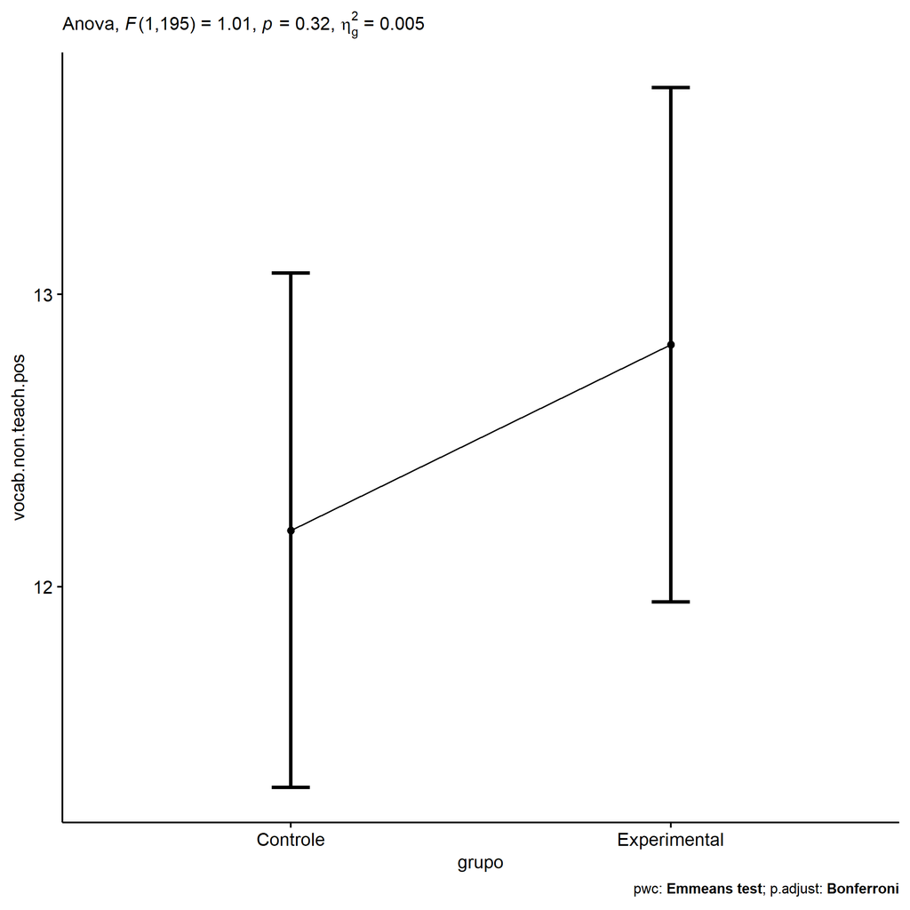

```r
if (!is.null(nrow(plots[["grupo"]]$data)))
  plots[["grupo"]] + ggplot2::scale_color_manual(values = color[["grupo"]])
```

```r
plots <- oneWayAncovaBoxPlots(
  wdat, "vocab.non.teach.pos", "grupo", aov, pwc, covar = "vocab.non.teach.pre",
  theme = "classic", color = color[["grupo"]],
  subtitle = which(aov$Effect == "grupo"))
```

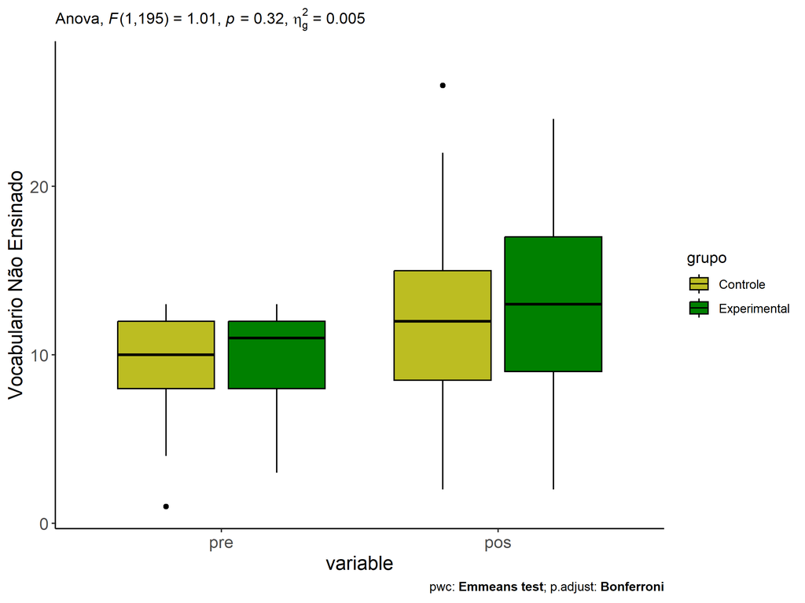

```r
if (length(unique(wdat[["grupo"]])) > 1)
  plots[["grupo"]] + ggplot2::ylab("Vocabulario Não Ensinado") + ggplot2::scale_x_discrete(labels=c('pre', 'pos'))
```

```r
if (length(unique(wdat.long[["grupo"]])) > 1)
  plots <- oneWayAncovaBoxPlots(
    wdat.long, "vocab.non.teach", "grupo", aov, pwc.long, pre.post = "time",
    theme = "classic", color = color$prepost)
```

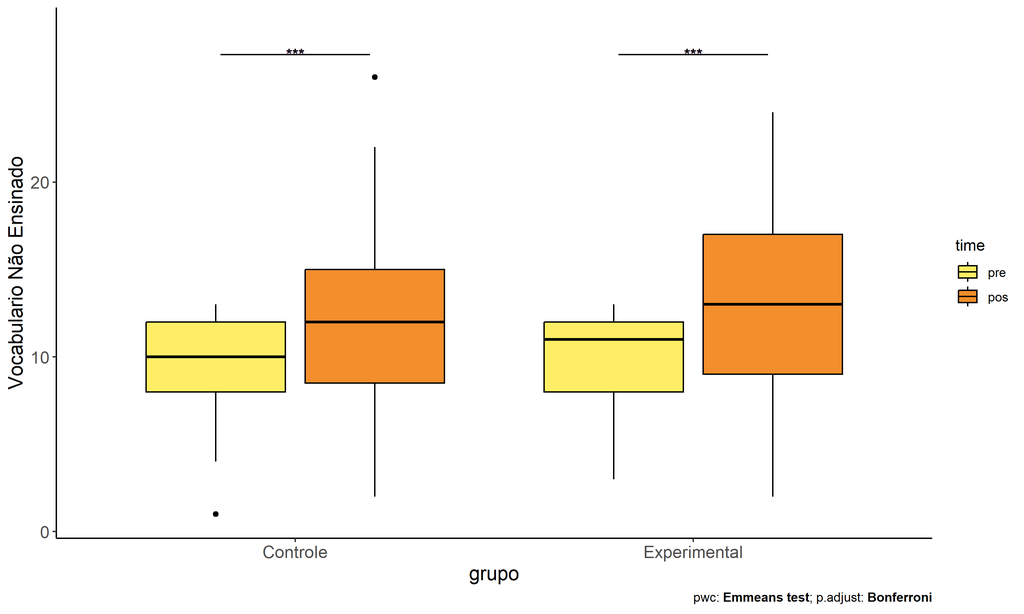

```r
if (length(unique(wdat.long[["grupo"]])) > 1)
  plots[["grupo"]] + ggplot2::ylab("Vocabulario Não Ensinado")
```

### Checking linearity assumption

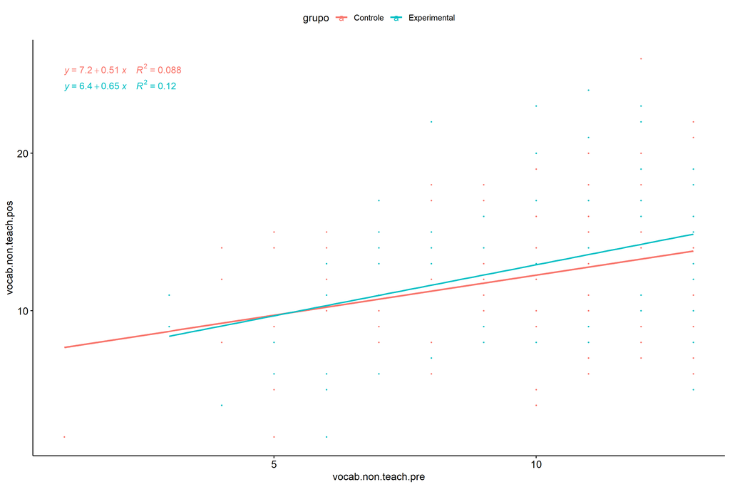

```r
ggscatter(wdat, x = "vocab.non.teach.pre", y = "vocab.non.teach.pos", size = 0.5,
          color = "grupo", add = "reg.line")+
  stat_regline_equation(
    aes(label =  paste(..eq.label.., ..rr.label.., sep = "~~~~"), color = grupo)
  )
```

### Checking normality and homogeneity

```r
res <- augment(lm(vocab.non.teach.pos ~ vocab.non.teach.pre + grupo, data = wdat))
```

```r
shapiro_test(res$.resid)
```

```
## # A tibble: 1 × 3
##   variable   statistic p.value
##   <chr>          <dbl>   <dbl>
## 1 res$.resid     0.987  0.0566
```

```r
levene_test(res, .resid ~ grupo)
```

```
## # A tibble: 1 × 4
##     df1   df2 statistic     p
##   <int> <int>     <dbl> <dbl>
## 1     1   196    0.0531 0.818
```

# ANCOVA and Pairwise for two factors **grupo:Sexo**

## Without remove non-normal data

```r
pdat = remove_group_data(dat[!is.na(dat[["grupo"]]) & !is.na(dat[["Sexo"]]),], "vocab.non.teach.pos", c("grupo","Sexo"))

pdat.long <- rbind(pdat[,c("id","grupo","Sexo")], pdat[,c("id","grupo","Sexo")])
pdat.long[["time"]] <- c(rep("pre", nrow(pdat)), rep("pos", nrow(pdat)))
pdat.long[["time"]] <- factor(pdat.long[["time"]], c("pre","pos"))
pdat.long[["vocab.non.teach"]] <- c(pdat[["vocab.non.teach.pre"]], pdat[["vocab.non.teach.pos"]])

aov = anova_test(pdat, vocab.non.teach.pos ~ vocab.non.teach.pre + grupo*Sexo)
laov[["grupo:Sexo"]] <- get_anova_table(aov)
```

```r
pwcs <- list()
pwcs[["Sexo"]] <- emmeans_test(
  group_by(pdat, grupo), vocab.non.teach.pos ~ Sexo,
  covariate = vocab.non.teach.pre, p.adjust.method = "bonferroni")
pwcs[["grupo"]] <- emmeans_test(
  group_by(pdat, Sexo), vocab.non.teach.pos ~ grupo,
  covariate = vocab.non.teach.pre, p.adjust.method = "bonferroni")

pwc <- plyr::rbind.fill(pwcs[["grupo"]], pwcs[["Sexo"]])
pwc <- pwc[,c("grupo","Sexo", colnames(pwc)[!colnames(pwc) %in% c("grupo","Sexo")])]
```

```r
pwc.long <- emmeans_test(dplyr::group_by_at(pdat.long, c("grupo","Sexo")),
                         vocab.non.teach ~ time,
                         p.adjust.method = "bonferroni")
lpwc[["grupo:Sexo"]] <- plyr::rbind.fill(pwc, pwc.long)
```

```r
ds <- get.descriptives(pdat, "vocab.non.teach.pos", c("grupo","Sexo"), covar = "vocab.non.teach.pre")
ds <- merge(ds[ds$variable != "vocab.non.teach.pre",],
            ds[ds$variable == "vocab.non.teach.pre", !colnames(ds) %in% c("variable")],
            by = c("grupo","Sexo"), all.x = T, suffixes = c("", ".vocab.non.teach.pre"))
ds <- merge(get_emmeans(pwcs[["grupo"]]), ds, by = c("grupo","Sexo"), suffixes = c(".emms", ""))
ds <- ds[,c("grupo","Sexo","n","mean.vocab.non.teach.pre","se.vocab.non.teach.pre","mean","se","emmean","se.emms")]

colnames(ds) <- c("grupo","Sexo", "N", paste0(c("M","SE")," (pre)"),
                  paste0(c("M","SE"), " (unadj)"), paste0(c("M", "SE"), " (adj)"))

lemms[["grupo:Sexo"]] <- ds
```

## Computing ANCOVA and PairWise After removing non-normal data (OK)

```r
wdat = pdat

res = residuals(lm(vocab.non.teach.pos ~ vocab.non.teach.pre + grupo*Sexo, data = wdat))
non.normal = getNonNormal(res, wdat$id, plimit = 0.05)

wdat = wdat[!wdat$id %in% non.normal,]

wdat.long <- rbind(wdat[,c("id","grupo","Sexo")], wdat[,c("id","grupo","Sexo")])
wdat.long[["time"]] <- c(rep("pre", nrow(wdat)), rep("pos", nrow(wdat)))
wdat.long[["time"]] <- factor(wdat.long[["time"]], c("pre","pos"))
wdat.long[["vocab.non.teach"]] <- c(wdat[["vocab.non.teach.pre"]], wdat[["vocab.non.teach.pos"]])


ldat[["grupo:Sexo"]] = wdat

(non.normal)
```

```
##   [1] "P3260" "P3548" "P852"  "P2931" "P1074" "P863"  "P2872" "P3106" "P818"  "P1859" "P2004" "P1754"
##  [13] "P1037" "P3113" "P2121" "P1613" "P1998" "P1057" "P822"  "P968"  "P1029" "P2161" "P890"  "P472"
##  [25] "P1873" "P3475" "P2000" "P2164" "P2877" "P1050" "P3254" "P583"  "P1008" "P1976" "P3503" "P539"
##  [37] "P879"  "P1656" "P3236" "P2841" "P1790" "P904"  "P856"  "P1987" "P1064" "P1757" "P443"  "P1862"
##  [49] "P3461" "P889"  "P915"  "P1659" "P3215" "P1720" "P3110" "P1622" "P1714" "P865"  "P1725" "P3111"
##  [61] "P3257" "P2162" "P2862" "P1718" "P930"  "P3542" "P2881" "P3486" "P2867" "P1690" "P490"  "P1975"
##  [73] "P476"  "P2311" "P2229" "P2900" "P1655" "P1691" "P824"  "P1758" "P868"  "P2903" "P3086" "P2137"
##  [85] "P883"  "P479"  "P1891" "P2242" "P2400" "P3158" "P3095" "P834"  "P2868" "P2842" "P486"  "P3166"
##  [97] "P500"  "P3562" "P1668" "P1789" "P1797" "P1767" "P2213" "P1799" "P971"  "P3463" "P1735" "P1051"
## [109] "P2908" "P973"  "P3488" "P2870" "P3494" "P471"  "P1654" "P954"  "P1694" "P3057" "P1666" "P3554"
## [121] "P2920" "P2056" "P3536" "P1920" "P3025" "P3305" "P975"  "P1969" "P2912" "P937"  "P845"  "P1775"
## [133] "P864"  "P442"  "P982"  "P940"  "P2831" "P877"  "P3477" "P3102" "P3551" "P2215" "P3196" "P2233"
## [145] "P1759" "P3017" "P2077" "P1892" "P582"  "P452"  "P821"  "P1082" "P1719" "P482"
```

```r
aov = anova_test(wdat, vocab.non.teach.pos ~ vocab.non.teach.pre + grupo*Sexo)
laov[["grupo:Sexo"]] <- merge(get_anova_table(aov), laov[["grupo:Sexo"]], by="Effect", suffixes = c("","'"))

(df = get_anova_table(aov))
```

```
## ANOVA Table (type II tests)
##
##                Effect DFn DFd      F        p p<.05   ges
## 1 vocab.non.teach.pre   1  44 56.991 1.81e-09     * 0.564
## 2               grupo   1  44  2.300 1.37e-01       0.050
## 3                Sexo   1  44  9.601 3.00e-03     * 0.179
## 4          grupo:Sexo   1  44  4.669 3.60e-02     * 0.096
```

| Effect | DFn | DFd | F | p | p<.05 | ges |
| --- | --- | --- | --- | --- | --- | --- |
| vocab.non.teach.pre | 1 | 44 | 56.991 | 0.000 | * | 0.564 |
| grupo | 1 | 44 | 2.300 | 0.137 |  | 0.050 |
| Sexo | 1 | 44 | 9.601 | 0.003 | * | 0.179 |
| grupo:Sexo | 1 | 44 | 4.669 | 0.036 | * | 0.096 |

```r
pwcs <- list()
pwcs[["Sexo"]] <- emmeans_test(
  group_by(wdat, grupo), vocab.non.teach.pos ~ Sexo,
  covariate = vocab.non.teach.pre, p.adjust.method = "bonferroni")
pwcs[["grupo"]] <- emmeans_test(
  group_by(wdat, Sexo), vocab.non.teach.pos ~ grupo,
  covariate = vocab.non.teach.pre, p.adjust.method = "bonferroni")

pwc <- plyr::rbind.fill(pwcs[["grupo"]], pwcs[["Sexo"]])
pwc <- pwc[,c("grupo","Sexo", colnames(pwc)[!colnames(pwc) %in% c("grupo","Sexo")])]
```

| grupo | Sexo | term | .y. | group1 | group2 | df | statistic | p | p.adj | p.adj.signif |
| --- | --- | --- | --- | --- | --- | --- | --- | --- | --- | --- |
|  | F | vocab.non.teach.pre*grupo | vocab.non.teach.pos | Controle | Experimental | 44 | 0.427 | 0.671 | 0.671 | ns |
|  | M | vocab.non.teach.pre*grupo | vocab.non.teach.pos | Controle | Experimental | 44 | -2.608 | 0.012 | 0.012 | * |
| Controle |  | vocab.non.teach.pre*Sexo | vocab.non.teach.pos | F | M | 44 | 3.660 | 0.001 | 0.001 | *** |
| Experimental |  | vocab.non.teach.pre*Sexo | vocab.non.teach.pos | F | M | 44 | 0.918 | 0.364 | 0.364 | ns |

```r
pwc.long <- emmeans_test(dplyr::group_by_at(wdat.long, c("grupo","Sexo")),
                         vocab.non.teach ~ time,
                         p.adjust.method = "bonferroni")
lpwc[["grupo:Sexo"]] <- merge(plyr::rbind.fill(pwc, pwc.long), lpwc[["grupo:Sexo"]], by=c("grupo","Sexo","term",".y.","group1","group2"), suffixes = c("","'"))
```

| grupo | Sexo | term | .y. | group1 | group2 | df | statistic | p | p.adj | p.adj.signif |
| --- | --- | --- | --- | --- | --- | --- | --- | --- | --- | --- |
| Controle | F | time | vocab.non.teach | pre | pos | 90 | -7.012 | 0 | 0 | **** |
| Controle | M | time | vocab.non.teach | pre | pos | 90 | -7.658 | 0 | 0 | **** |
| Experimental | F | time | vocab.non.teach | pre | pos | 90 | -9.204 | 0 | 0 | **** |
| Experimental | M | time | vocab.non.teach | pre | pos | 90 | -7.136 | 0 | 0 | **** |

```r
ds <- get.descriptives(wdat, "vocab.non.teach.pos", c("grupo","Sexo"), covar = "vocab.non.teach.pre")
ds <- merge(ds[ds$variable != "vocab.non.teach.pre",],
            ds[ds$variable == "vocab.non.teach.pre", !colnames(ds) %in% c("variable")],
            by = c("grupo","Sexo"), all.x = T, suffixes = c("", ".vocab.non.teach.pre"))
ds <- merge(get_emmeans(pwcs[["grupo"]]), ds, by = c("grupo","Sexo"), suffixes = c(".emms", ""))
ds <- ds[,c("grupo","Sexo","n","mean.vocab.non.teach.pre","se.vocab.non.teach.pre","mean","se","emmean","se.emms")]

colnames(ds) <- c("grupo","Sexo", "N", paste0(c("M","SE")," (pre)"),
                  paste0(c("M","SE"), " (unadj)"), paste0(c("M", "SE"), " (adj)"))

lemms[["grupo:Sexo"]] <- merge(ds, lemms[["grupo:Sexo"]], by=c("grupo","Sexo"), suffixes = c("","'"))
```

| grupo | Sexo | N | M (pre) | SE (pre) | M (unadj) | SE (unadj) | M (adj) | SE (adj) |
| --- | --- | --- | --- | --- | --- | --- | --- | --- |
| Controle | F | 9 | 10.222 | 0.940 | 17.333 | 0.553 | 17.022 | 0.366 |
| Controle | M | 13 | 8.000 | 0.751 | 14.462 | 0.418 | 15.214 | 0.319 |
| Experimental | F | 16 | 10.062 | 0.504 | 17.062 | 0.370 | 16.827 | 0.275 |
| Experimental | M | 11 | 10.182 | 0.872 | 16.727 | 0.589 | 16.435 | 0.331 |

### Plots for ancova

```r
plots <- twoWayAncovaPlots(
  wdat, "vocab.non.teach.pos", c("grupo","Sexo"), aov, pwcs, addParam = c("mean_se"),
  font.label.size=10, step.increase=0.05, p.label="p.adj",
  subtitle = which(aov$Effect == "grupo:Sexo"))
```

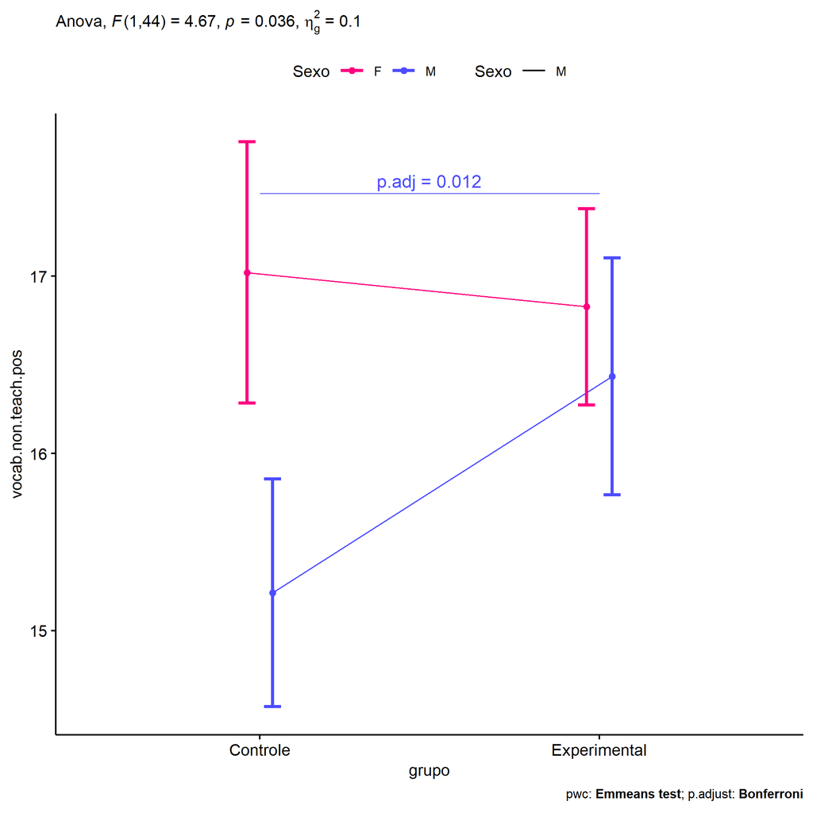

```r
if (!is.null(plots[["grupo"]]))
  plots[["grupo"]] + ggplot2::scale_color_manual(values = color[["Sexo"]])
```

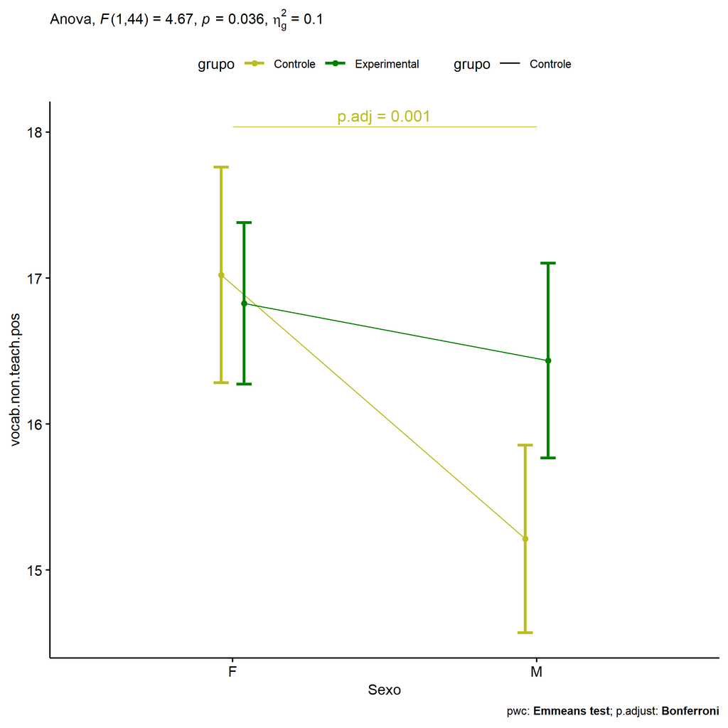

```r
if (!is.null(plots[["Sexo"]]))
  plots[["Sexo"]] + ggplot2::scale_color_manual(values = color[["grupo"]])
```

```r
plots <- twoWayAncovaBoxPlots(
  wdat, "vocab.non.teach.pos", c("grupo","Sexo"), aov, pwcs, covar = "vocab.non.teach.pre",
  theme = "classic", color = color[["grupo:Sexo"]],
  subtitle = which(aov$Effect == "grupo:Sexo"))
```

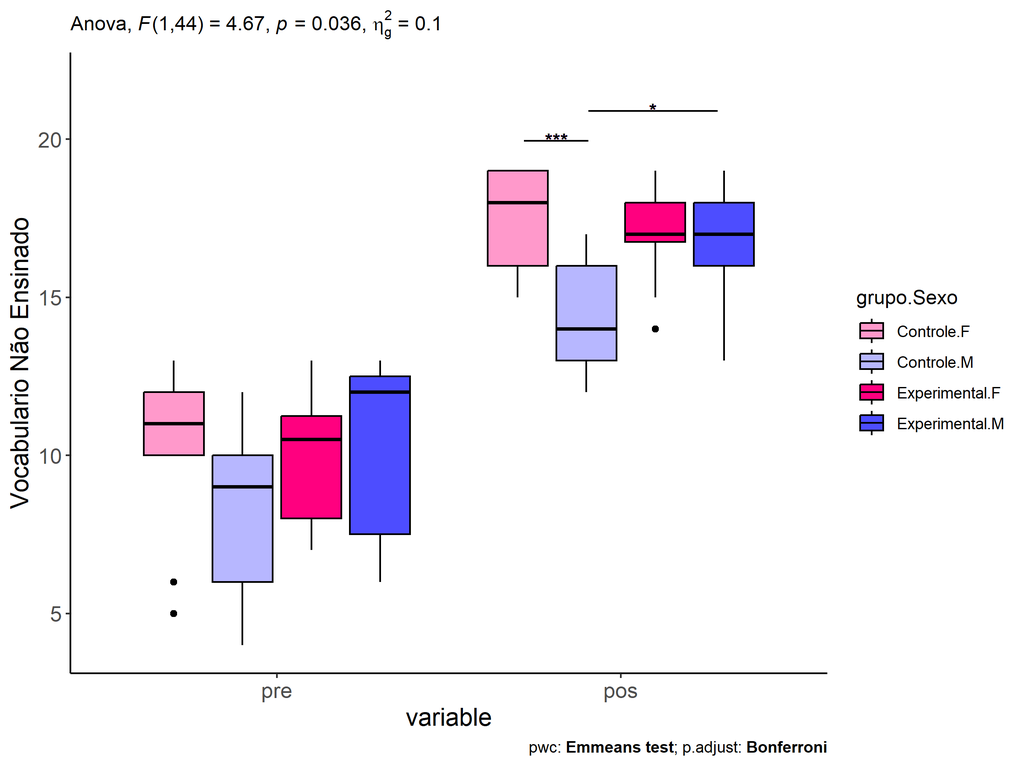

```r
plots[["grupo:Sexo"]] + ggplot2::ylab("Vocabulario Não Ensinado") + ggplot2::scale_x_discrete(labels=c('pre', 'pos'))
```

```r
plots <- twoWayAncovaBoxPlots(
  wdat.long, "vocab.non.teach", c("grupo","Sexo"), aov, pwc.long, pre.post = "time",
  theme = "classic", color = color$prepost)
```

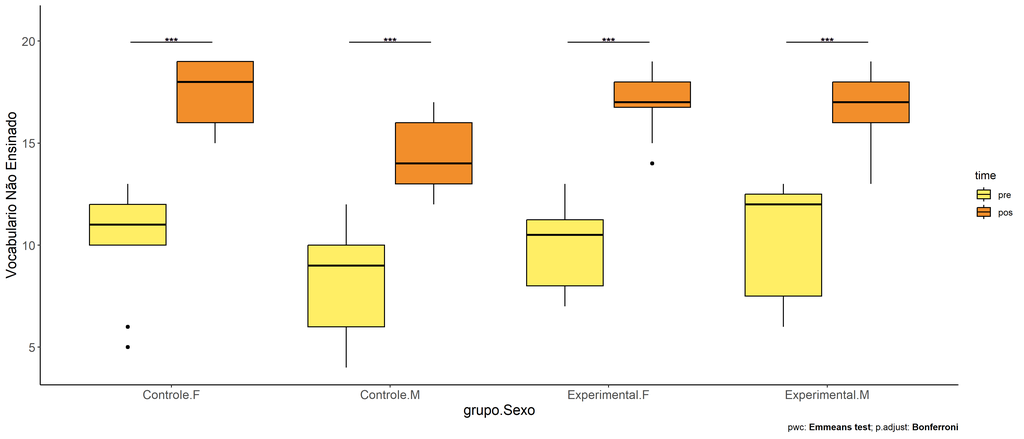

```r
plots[["grupo:Sexo"]] + ggplot2::ylab("Vocabulario Não Ensinado")
```

### Checking linearity assumption

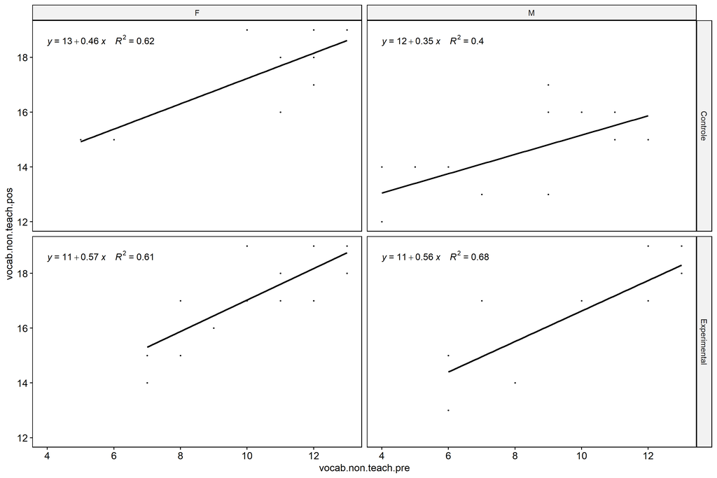

```r
ggscatter(wdat, x = "vocab.non.teach.pre", y = "vocab.non.teach.pos", size = 0.5,
          facet.by = c("grupo","Sexo"), add = "reg.line")+
  stat_regline_equation(
    aes(label =  paste(..eq.label.., ..rr.label.., sep = "~~~~"))
  )
```

### Checking normality and homogeneity

```r
res <- augment(lm(vocab.non.teach.pos ~ vocab.non.teach.pre + grupo*Sexo, data = wdat))
```

```r
shapiro_test(res$.resid)
```

```
## # A tibble: 1 × 3
##   variable   statistic p.value
##   <chr>          <dbl>   <dbl>
## 1 res$.resid     0.977   0.458
```

```r
levene_test(res, .resid ~ grupo*Sexo)
```

```
## # A tibble: 1 × 4
##     df1   df2 statistic     p
##   <int> <int>     <dbl> <dbl>
## 1     3    45     0.511 0.677
```

# ANCOVA and Pairwise for two factors **grupo:Zona**

## Without remove non-normal data

```r
pdat = remove_group_data(dat[!is.na(dat[["grupo"]]) & !is.na(dat[["Zona"]]),], "vocab.non.teach.pos", c("grupo","Zona"))

pdat.long <- rbind(pdat[,c("id","grupo","Zona")], pdat[,c("id","grupo","Zona")])
pdat.long[["time"]] <- c(rep("pre", nrow(pdat)), rep("pos", nrow(pdat)))
pdat.long[["time"]] <- factor(pdat.long[["time"]], c("pre","pos"))
pdat.long[["vocab.non.teach"]] <- c(pdat[["vocab.non.teach.pre"]], pdat[["vocab.non.teach.pos"]])

aov = anova_test(pdat, vocab.non.teach.pos ~ vocab.non.teach.pre + grupo*Zona)
laov[["grupo:Zona"]] <- get_anova_table(aov)
```

```r
pwcs <- list()
pwcs[["Zona"]] <- emmeans_test(
  group_by(pdat, grupo), vocab.non.teach.pos ~ Zona,
  covariate = vocab.non.teach.pre, p.adjust.method = "bonferroni")
pwcs[["grupo"]] <- emmeans_test(
  group_by(pdat, Zona), vocab.non.teach.pos ~ grupo,
  covariate = vocab.non.teach.pre, p.adjust.method = "bonferroni")

pwc <- plyr::rbind.fill(pwcs[["grupo"]], pwcs[["Zona"]])
pwc <- pwc[,c("grupo","Zona", colnames(pwc)[!colnames(pwc) %in% c("grupo","Zona")])]
```

```r
pwc.long <- emmeans_test(dplyr::group_by_at(pdat.long, c("grupo","Zona")),
                         vocab.non.teach ~ time,
                         p.adjust.method = "bonferroni")
lpwc[["grupo:Zona"]] <- plyr::rbind.fill(pwc, pwc.long)
```

```r
ds <- get.descriptives(pdat, "vocab.non.teach.pos", c("grupo","Zona"), covar = "vocab.non.teach.pre")
ds <- merge(ds[ds$variable != "vocab.non.teach.pre",],
            ds[ds$variable == "vocab.non.teach.pre", !colnames(ds) %in% c("variable")],
            by = c("grupo","Zona"), all.x = T, suffixes = c("", ".vocab.non.teach.pre"))
ds <- merge(get_emmeans(pwcs[["grupo"]]), ds, by = c("grupo","Zona"), suffixes = c(".emms", ""))
ds <- ds[,c("grupo","Zona","n","mean.vocab.non.teach.pre","se.vocab.non.teach.pre","mean","se","emmean","se.emms")]

colnames(ds) <- c("grupo","Zona", "N", paste0(c("M","SE")," (pre)"),
                  paste0(c("M","SE"), " (unadj)"), paste0(c("M", "SE"), " (adj)"))

lemms[["grupo:Zona"]] <- ds
```

## Computing ANCOVA and PairWise After removing non-normal data (OK)

```r
wdat = pdat

res = residuals(lm(vocab.non.teach.pos ~ vocab.non.teach.pre + grupo*Zona, data = wdat))
non.normal = getNonNormal(res, wdat$id, plimit = 0.05)

wdat = wdat[!wdat$id %in% non.normal,]

wdat.long <- rbind(wdat[,c("id","grupo","Zona")], wdat[,c("id","grupo","Zona")])
wdat.long[["time"]] <- c(rep("pre", nrow(wdat)), rep("pos", nrow(wdat)))
wdat.long[["time"]] <- factor(wdat.long[["time"]], c("pre","pos"))
wdat.long[["vocab.non.teach"]] <- c(wdat[["vocab.non.teach.pre"]], wdat[["vocab.non.teach.pos"]])


ldat[["grupo:Zona"]] = wdat

(non.normal)
```

```
## [1] "P3260" "P852"
```

```r
aov = anova_test(wdat, vocab.non.teach.pos ~ vocab.non.teach.pre + grupo*Zona)
laov[["grupo:Zona"]] <- merge(get_anova_table(aov), laov[["grupo:Zona"]], by="Effect", suffixes = c("","'"))

(df = get_anova_table(aov))
```

```
## ANOVA Table (type II tests)
##
##                Effect DFn DFd      F        p p<.05      ges
## 1 vocab.non.teach.pre   1 138 16.602 7.74e-05     * 0.107000
## 2               grupo   1 138  1.770 1.86e-01       0.013000
## 3                Zona   1 138  0.161 6.89e-01       0.001000
## 4          grupo:Zona   1 138  0.041 8.40e-01       0.000297
```

| Effect | DFn | DFd | F | p | p<.05 | ges |
| --- | --- | --- | --- | --- | --- | --- |
| vocab.non.teach.pre | 1 | 138 | 16.602 | 0.000 | * | 0.107 |
| grupo | 1 | 138 | 1.770 | 0.186 |  | 0.013 |
| Zona | 1 | 138 | 0.161 | 0.689 |  | 0.001 |
| grupo:Zona | 1 | 138 | 0.041 | 0.840 |  | 0.000 |

```r
pwcs <- list()
pwcs[["Zona"]] <- emmeans_test(
  group_by(wdat, grupo), vocab.non.teach.pos ~ Zona,
  covariate = vocab.non.teach.pre, p.adjust.method = "bonferroni")
pwcs[["grupo"]] <- emmeans_test(
  group_by(wdat, Zona), vocab.non.teach.pos ~ grupo,
  covariate = vocab.non.teach.pre, p.adjust.method = "bonferroni")

pwc <- plyr::rbind.fill(pwcs[["grupo"]], pwcs[["Zona"]])
pwc <- pwc[,c("grupo","Zona", colnames(pwc)[!colnames(pwc) %in% c("grupo","Zona")])]
```

| grupo | Zona | term | .y. | group1 | group2 | df | statistic | p | p.adj | p.adj.signif |
| --- | --- | --- | --- | --- | --- | --- | --- | --- | --- | --- |
|  | Rural | vocab.non.teach.pre*grupo | vocab.non.teach.pos | Controle | Experimental | 138 | -1.014 | 0.312 | 0.312 | ns |
|  | Urbana | vocab.non.teach.pre*grupo | vocab.non.teach.pos | Controle | Experimental | 138 | -0.882 | 0.379 | 0.379 | ns |
| Controle |  | vocab.non.teach.pre*Zona | vocab.non.teach.pos | Rural | Urbana | 138 | 0.420 | 0.675 | 0.675 | ns |
| Experimental |  | vocab.non.teach.pre*Zona | vocab.non.teach.pos | Rural | Urbana | 138 | 0.159 | 0.874 | 0.874 | ns |

```r
pwc.long <- emmeans_test(dplyr::group_by_at(wdat.long, c("grupo","Zona")),
                         vocab.non.teach ~ time,
                         p.adjust.method = "bonferroni")
lpwc[["grupo:Zona"]] <- merge(plyr::rbind.fill(pwc, pwc.long), lpwc[["grupo:Zona"]], by=c("grupo","Zona","term",".y.","group1","group2"), suffixes = c("","'"))
```

| grupo | Zona | term | .y. | group1 | group2 | df | statistic | p | p.adj | p.adj.signif |
| --- | --- | --- | --- | --- | --- | --- | --- | --- | --- | --- |
| Controle | Rural | time | vocab.non.teach | pre | pos | 278 | -2.624 | 0.009 | 0.009 | ** |
| Controle | Urbana | time | vocab.non.teach | pre | pos | 278 | -1.287 | 0.199 | 0.199 | ns |
| Experimental | Rural | time | vocab.non.teach | pre | pos | 278 | -3.860 | 0.000 | 0.000 | *** |
| Experimental | Urbana | time | vocab.non.teach | pre | pos | 278 | -2.191 | 0.029 | 0.029 | * |

```r
ds <- get.descriptives(wdat, "vocab.non.teach.pos", c("grupo","Zona"), covar = "vocab.non.teach.pre")
ds <- merge(ds[ds$variable != "vocab.non.teach.pre",],
            ds[ds$variable == "vocab.non.teach.pre", !colnames(ds) %in% c("variable")],
            by = c("grupo","Zona"), all.x = T, suffixes = c("", ".vocab.non.teach.pre"))
ds <- merge(get_emmeans(pwcs[["grupo"]]), ds, by = c("grupo","Zona"), suffixes = c(".emms", ""))
ds <- ds[,c("grupo","Zona","n","mean.vocab.non.teach.pre","se.vocab.non.teach.pre","mean","se","emmean","se.emms")]

colnames(ds) <- c("grupo","Zona", "N", paste0(c("M","SE")," (pre)"),
                  paste0(c("M","SE"), " (unadj)"), paste0(c("M", "SE"), " (adj)"))

lemms[["grupo:Zona"]] <- merge(ds, lemms[["grupo:Zona"]], by=c("grupo","Zona"), suffixes = c("","'"))
```

| grupo | Zona | N | M (pre) | SE (pre) | M (unadj) | SE (unadj) | M (adj) | SE (adj) |
| --- | --- | --- | --- | --- | --- | --- | --- | --- |
| Controle | Rural | 51 | 9.941 | 0.389 | 11.961 | 0.691 | 11.975 | 0.641 |
| Controle | Urbana | 18 | 9.500 | 0.567 | 11.167 | 0.919 | 11.448 | 1.082 |
| Experimental | Rural | 50 | 9.800 | 0.384 | 12.800 | 0.713 | 12.900 | 0.648 |
| Experimental | Urbana | 24 | 10.708 | 0.440 | 13.167 | 0.974 | 12.718 | 0.941 |

### Plots for ancova

```r
plots <- twoWayAncovaPlots(
  wdat, "vocab.non.teach.pos", c("grupo","Zona"), aov, pwcs, addParam = c("mean_se"),
  font.label.size=10, step.increase=0.05, p.label="p.adj",
  subtitle = which(aov$Effect == "grupo:Zona"))
```

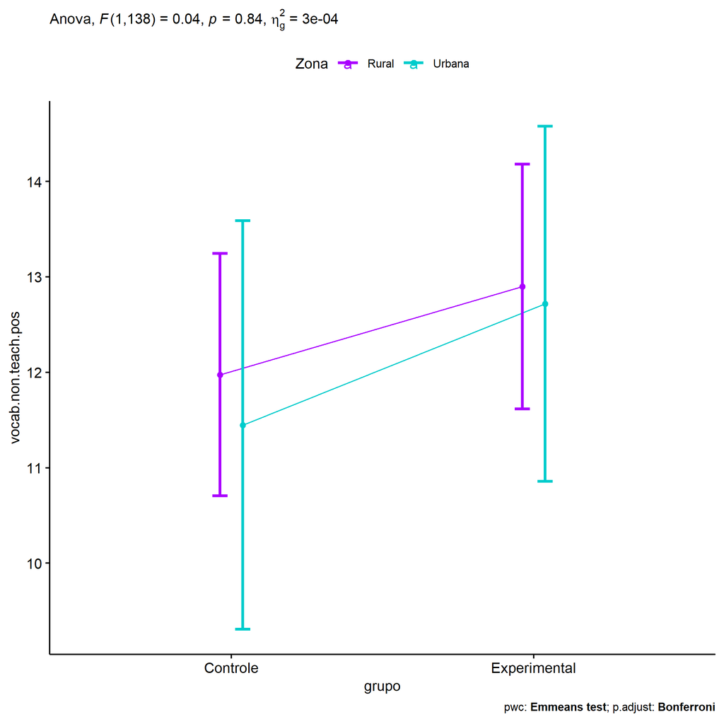

```r
if (!is.null(plots[["grupo"]]))
  plots[["grupo"]] + ggplot2::scale_color_manual(values = color[["Zona"]])
```

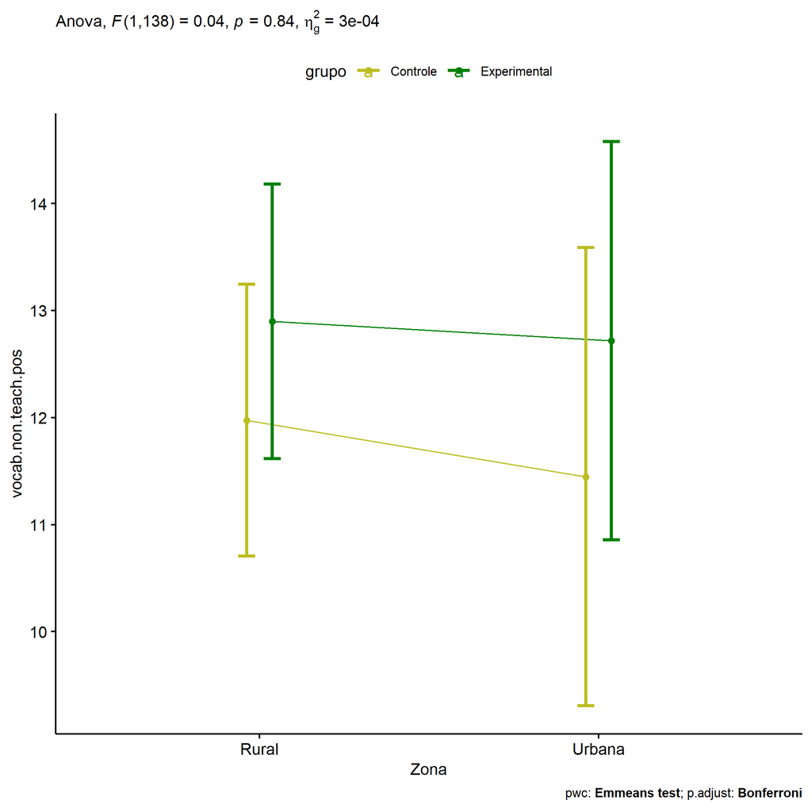

```r
if (!is.null(plots[["Zona"]]))
  plots[["Zona"]] + ggplot2::scale_color_manual(values = color[["grupo"]])
```

```r
plots <- twoWayAncovaBoxPlots(
  wdat, "vocab.non.teach.pos", c("grupo","Zona"), aov, pwcs, covar = "vocab.non.teach.pre",
  theme = "classic", color = color[["grupo:Zona"]],
  subtitle = which(aov$Effect == "grupo:Zona"))
```

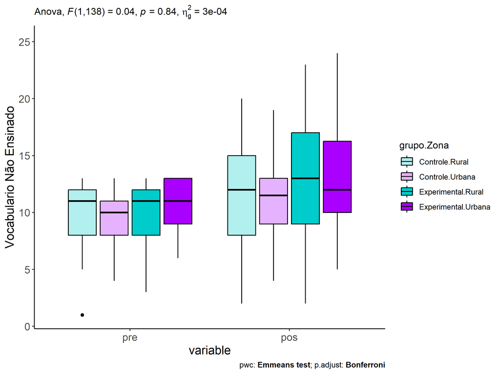

```r
plots[["grupo:Zona"]] + ggplot2::ylab("Vocabulario Não Ensinado") + ggplot2::scale_x_discrete(labels=c('pre', 'pos'))
```

```r
plots <- twoWayAncovaBoxPlots(
  wdat.long, "vocab.non.teach", c("grupo","Zona"), aov, pwc.long, pre.post = "time",
  theme = "classic", color = color$prepost)
```

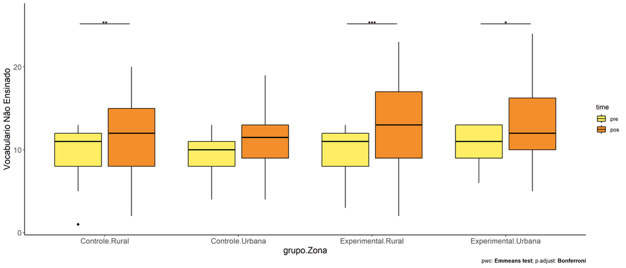

```r
plots[["grupo:Zona"]] + ggplot2::ylab("Vocabulario Não Ensinado")
```

### Checking linearity assumption

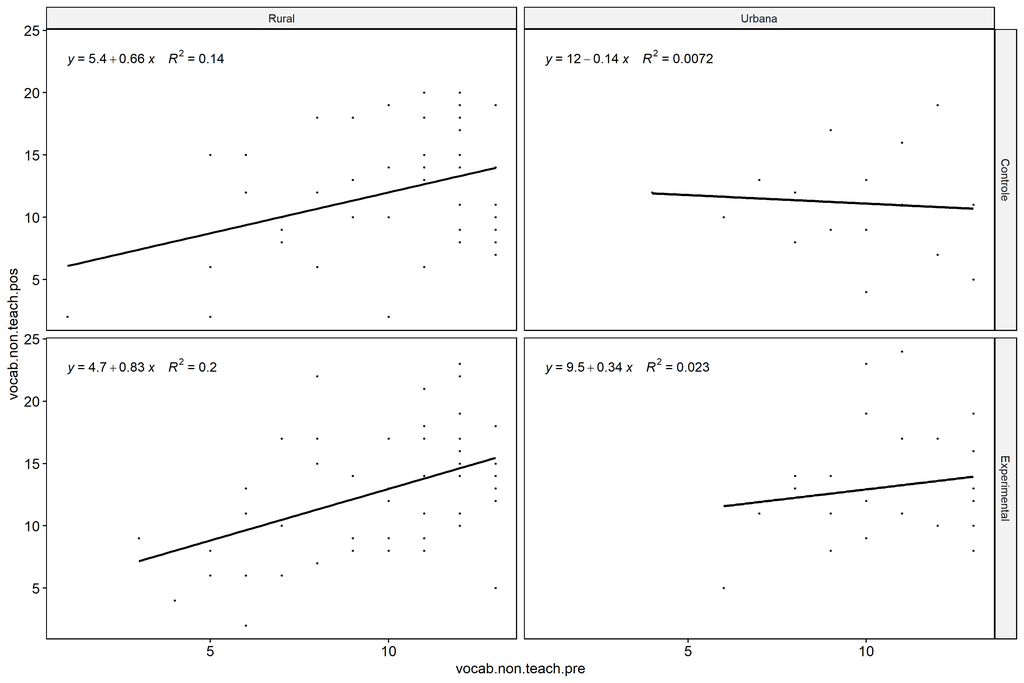

```r
ggscatter(wdat, x = "vocab.non.teach.pre", y = "vocab.non.teach.pos", size = 0.5,
          facet.by = c("grupo","Zona"), add = "reg.line")+
  stat_regline_equation(
    aes(label =  paste(..eq.label.., ..rr.label.., sep = "~~~~"))
  )
```

### Checking normality and homogeneity

```r
res <- augment(lm(vocab.non.teach.pos ~ vocab.non.teach.pre + grupo*Zona, data = wdat))
```

```r
shapiro_test(res$.resid)
```

```
## # A tibble: 1 × 3
##   variable   statistic p.value
##   <chr>          <dbl>   <dbl>
## 1 res$.resid     0.985   0.129
```

```r
levene_test(res, .resid ~ grupo*Zona)
```

```
## # A tibble: 1 × 4
##     df1   df2 statistic     p
##   <int> <int>     <dbl> <dbl>
## 1     3   139     0.146 0.932
```

# ANCOVA and Pairwise for two factors **grupo:Cor.Raca**

## Without remove non-normal data

```r
pdat = remove_group_data(dat[!is.na(dat[["grupo"]]) & !is.na(dat[["Cor.Raca"]]),], "vocab.non.teach.pos", c("grupo","Cor.Raca"))
pdat.long <- rbind(pdat[,c("id","grupo","Cor.Raca")], pdat[,c("id","grupo","Cor.Raca")])
pdat.long[["time"]] <- c(rep("pre", nrow(pdat)), rep("pos", nrow(pdat)))
pdat.long[["time"]] <- factor(pdat.long[["time"]], c("pre","pos"))
pdat.long[["vocab.non.teach"]] <- c(pdat[["vocab.non.teach.pre"]], pdat[["vocab.non.teach.pos"]])

aov = anova_test(pdat, vocab.non.teach.pos ~ vocab.non.teach.pre + grupo*Cor.Raca)
laov[["grupo:Cor.Raca"]] <- get_anova_table(aov)
```

```r
pwcs <- list()
pwcs[["Cor.Raca"]] <- emmeans_test(
  group_by(pdat, grupo), vocab.non.teach.pos ~ Cor.Raca,
  covariate = vocab.non.teach.pre, p.adjust.method = "bonferroni")
pwcs[["grupo"]] <- emmeans_test(
  group_by(pdat, Cor.Raca), vocab.non.teach.pos ~ grupo,
  covariate = vocab.non.teach.pre, p.adjust.method = "bonferroni")

pwc <- plyr::rbind.fill(pwcs[["grupo"]], pwcs[["Cor.Raca"]])
pwc <- pwc[,c("grupo","Cor.Raca", colnames(pwc)[!colnames(pwc) %in% c("grupo","Cor.Raca")])]
```

```r
pwc.long <- emmeans_test(dplyr::group_by_at(pdat.long, c("grupo","Cor.Raca")),
                         vocab.non.teach ~ time,
                         p.adjust.method = "bonferroni")
lpwc[["grupo:Cor.Raca"]] <- plyr::rbind.fill(pwc, pwc.long)
```

```r
ds <- get.descriptives(pdat, "vocab.non.teach.pos", c("grupo","Cor.Raca"), covar = "vocab.non.teach.pre")
ds <- merge(ds[ds$variable != "vocab.non.teach.pre",],
            ds[ds$variable == "vocab.non.teach.pre", !colnames(ds) %in% c("variable")],
            by = c("grupo","Cor.Raca"), all.x = T, suffixes = c("", ".vocab.non.teach.pre"))
ds <- merge(get_emmeans(pwcs[["grupo"]]), ds, by = c("grupo","Cor.Raca"), suffixes = c(".emms", ""))
ds <- ds[,c("grupo","Cor.Raca","n","mean.vocab.non.teach.pre","se.vocab.non.teach.pre","mean","se","emmean","se.emms")]

colnames(ds) <- c("grupo","Cor.Raca", "N", paste0(c("M","SE")," (pre)"),
                  paste0(c("M","SE"), " (unadj)"), paste0(c("M", "SE"), " (adj)"))

lemms[["grupo:Cor.Raca"]] <- ds
```

## Computing ANCOVA and PairWise After removing non-normal data (OK)

```r
wdat = pdat

res = residuals(lm(vocab.non.teach.pos ~ vocab.non.teach.pre + grupo*Cor.Raca, data = wdat))
non.normal = getNonNormal(res, wdat$id, plimit = 0.05)

wdat = wdat[!wdat$id %in% non.normal,]

wdat.long <- rbind(wdat[,c("id","grupo","Cor.Raca")], wdat[,c("id","grupo","Cor.Raca")])
wdat.long[["time"]] <- c(rep("pre", nrow(wdat)), rep("pos", nrow(wdat)))
wdat.long[["time"]] <- factor(wdat.long[["time"]], c("pre","pos"))
wdat.long[["vocab.non.teach"]] <- c(wdat[["vocab.non.teach.pre"]], wdat[["vocab.non.teach.pos"]])


ldat[["grupo:Cor.Raca"]] = wdat

(non.normal)
```

```
## [1] "P3260"
```

```r
aov = anova_test(wdat, vocab.non.teach.pos ~ vocab.non.teach.pre + grupo*Cor.Raca)
laov[["grupo:Cor.Raca"]] <- merge(get_anova_table(aov), laov[["grupo:Cor.Raca"]], by="Effect", suffixes = c("","'"))

(df = get_anova_table(aov))
```

```
## ANOVA Table (type II tests)
##
##                Effect DFn DFd     F     p p<.05   ges
## 1 vocab.non.teach.pre   1  85 3.405 0.068       0.039
## 2               grupo   1  85 5.743 0.019     * 0.063
## 3            Cor.Raca   2  85 0.095 0.909       0.002
## 4      grupo:Cor.Raca   1  85 0.878 0.351       0.010
```

| Effect | DFn | DFd | F | p | p<.05 | ges |
| --- | --- | --- | --- | --- | --- | --- |
| vocab.non.teach.pre | 1 | 85 | 3.405 | 0.068 |  | 0.039 |
| grupo | 1 | 85 | 5.743 | 0.019 | * | 0.063 |
| Cor.Raca | 2 | 85 | 0.095 | 0.909 |  | 0.002 |
| grupo:Cor.Raca | 1 | 85 | 0.878 | 0.351 |  | 0.010 |

```r
pwcs <- list()
pwcs[["Cor.Raca"]] <- emmeans_test(
  group_by(wdat, grupo), vocab.non.teach.pos ~ Cor.Raca,
  covariate = vocab.non.teach.pre, p.adjust.method = "bonferroni")
pwcs[["grupo"]] <- emmeans_test(
  group_by(wdat, Cor.Raca), vocab.non.teach.pos ~ grupo,
  covariate = vocab.non.teach.pre, p.adjust.method = "bonferroni")

pwc <- plyr::rbind.fill(pwcs[["grupo"]], pwcs[["Cor.Raca"]])
pwc <- pwc[,c("grupo","Cor.Raca", colnames(pwc)[!colnames(pwc) %in% c("grupo","Cor.Raca")])]
```

| grupo | Cor.Raca | term | .y. | group1 | group2 | df | statistic | p | p.adj | p.adj.signif |
| --- | --- | --- | --- | --- | --- | --- | --- | --- | --- | --- |
|  | Branca | vocab.non.teach.pre*grupo | vocab.non.teach.pos | Controle | Experimental | 85 | 0.023 | 0.982 | 0.982 | ns |
|  | Indígena | vocab.non.teach.pre*grupo | vocab.non.teach.pos | Controle | Experimental |  |  |  |  |  |
|  | Parda | vocab.non.teach.pre*grupo | vocab.non.teach.pos | Controle | Experimental | 85 | -2.573 | 0.012 | 0.012 | * |
| Controle |  | vocab.non.teach.pre*Cor.Raca | vocab.non.teach.pos | Branca | Indígena |  |  |  |  |  |
| Controle |  | vocab.non.teach.pre*Cor.Raca | vocab.non.teach.pos | Branca | Parda | 85 | 0.417 | 0.678 | 0.678 | ns |
| Controle |  | vocab.non.teach.pre*Cor.Raca | vocab.non.teach.pos | Indígena | Parda |  |  |  |  |  |
| Experimental |  | vocab.non.teach.pre*Cor.Raca | vocab.non.teach.pos | Branca | Indígena | 85 | -0.397 | 0.692 | 1.000 | ns |
| Experimental |  | vocab.non.teach.pre*Cor.Raca | vocab.non.teach.pos | Branca | Parda | 85 | -0.894 | 0.374 | 1.000 | ns |
| Experimental |  | vocab.non.teach.pre*Cor.Raca | vocab.non.teach.pos | Indígena | Parda | 85 | -0.428 | 0.670 | 1.000 | ns |

```r
pwc.long <- emmeans_test(dplyr::group_by_at(wdat.long, c("grupo","Cor.Raca")),
                         vocab.non.teach ~ time,
                         p.adjust.method = "bonferroni")
lpwc[["grupo:Cor.Raca"]] <- merge(plyr::rbind.fill(pwc, pwc.long), lpwc[["grupo:Cor.Raca"]], by=c("grupo","Cor.Raca","term",".y.","group1","group2"), suffixes = c("","'"))
```

| grupo | Cor.Raca | term | .y. | group1 | group2 | df | statistic | p | p.adj | p.adj.signif |
| --- | --- | --- | --- | --- | --- | --- | --- | --- | --- | --- |
| Controle | Branca | time | vocab.non.teach | pre | pos | 172 | -1.041 | 0.299 | 0.299 | ns |
| Controle | Indígena | time | vocab.non.teach | pre | pos |  |  |  |  |  |
| Controle | Parda | time | vocab.non.teach | pre | pos | 172 | -1.263 | 0.208 | 0.208 | ns |
| Experimental | Branca | time | vocab.non.teach | pre | pos | 172 | -0.407 | 0.684 | 0.684 | ns |
| Experimental | Indígena | time | vocab.non.teach | pre | pos | 172 | -1.265 | 0.208 | 0.208 | ns |
| Experimental | Parda | time | vocab.non.teach | pre | pos | 172 | -4.551 | 0.000 | 0.000 | **** |

```r
ds <- get.descriptives(wdat, "vocab.non.teach.pos", c("grupo","Cor.Raca"), covar = "vocab.non.teach.pre")
ds <- merge(ds[ds$variable != "vocab.non.teach.pre",],
            ds[ds$variable == "vocab.non.teach.pre", !colnames(ds) %in% c("variable")],
            by = c("grupo","Cor.Raca"), all.x = T, suffixes = c("", ".vocab.non.teach.pre"))
ds <- merge(get_emmeans(pwcs[["grupo"]]), ds, by = c("grupo","Cor.Raca"), suffixes = c(".emms", ""))
ds <- ds[,c("grupo","Cor.Raca","n","mean.vocab.non.teach.pre","se.vocab.non.teach.pre","mean","se","emmean","se.emms")]

colnames(ds) <- c("grupo","Cor.Raca", "N", paste0(c("M","SE")," (pre)"),
                  paste0(c("M","SE"), " (unadj)"), paste0(c("M", "SE"), " (adj)"))

lemms[["grupo:Cor.Raca"]] <- merge(ds, lemms[["grupo:Cor.Raca"]], by=c("grupo","Cor.Raca"), suffixes = c("","'"))
```

| grupo | Cor.Raca | N | M (pre) | SE (pre) | M (unadj) | SE (unadj) | M (adj) | SE (adj) |
| --- | --- | --- | --- | --- | --- | --- | --- | --- |
| Controle | Branca | 6 | 9.500 | 0.885 | 11.833 | 1.869 | 12.072 | 1.986 |
| Controle | Parda | 35 | 9.943 | 0.414 | 11.114 | 0.688 | 11.176 | 0.821 |
| Experimental | Branca | 5 | 11.600 | 0.600 | 12.600 | 2.379 | 12.003 | 2.195 |
| Experimental | Indígena | 6 | 10.500 | 0.764 | 13.333 | 1.145 | 13.174 | 1.984 |
| Experimental | Parda | 39 | 10.077 | 0.415 | 14.077 | 0.923 | 14.086 | 0.777 |